# Assignment4_Phoenix

**Group Name**: Phoenix

- **Member 1**  
  Name: Shan YUJIE  
  Number: 2180790  
  Email: shan.2180790@studenti.uniroma1.it
- **Member 2**  
  Name: Sun YUNYANG  
  Number: 2190190  
  Email: sun.2190190@studenti.uniroma1.it
- **Member 3**  
  Name: KONG YAEWEN  
  Number: 2190124  
  Email: kong.2190124@studenti.uniroma1.it
- **Member 4**  
  Name: RU MENGYU  
  Number: 2179930  
  Email: ru.2179930@studenti.uniroma1.it
- **Member 5**  
  Name: LIANG HUAMING  
  Number: 2180952  
  Email: liang.2180952@studenti.uniroma1.it

## Exercise 1: Effect of Sample Size

This section investigates how the number of samples affects Lasso’s ability to recover true model coefficients.

```
   Sample Size  Optimal Alpha   Test R²  Test MSE  Non-zero Coefficients  \
0          100       0.091906  0.993319  0.645553                     24
1          200       0.073545  0.970439  1.282625                     22
2         1000       0.036822  0.977214  1.062453                     23

   Correctly Selected  False Positives
0                  10               14
1                  10               12
2                  10               13
```

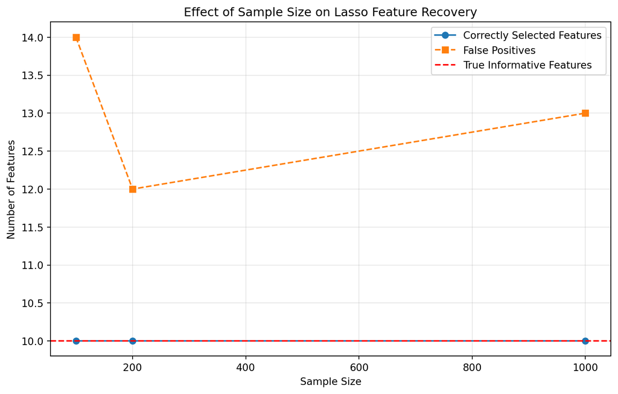

```python
import numpy as np
import pandas as pd
import matplotlib.pyplot as plt
from sklearn.linear_model import LassoCV
from sklearn.metrics import mean_squared_error, r2_score
from sklearn.preprocessing import StandardScaler
from sklearn.model_selection import train_test_split

n_features = 50
n_informative = 10
noise_level = 1.0
sample_sizes = [100, 200, 1000]
results = []
np.random.seed(42)

for n_samples in sample_sizes:
    X = np.random.randn(n_samples, n_features)
    true_coefficients = np.zeros(n_features)
    informative_features = np.random.choice(n_features, n_informative, replace=False)
    for idx in informative_features:
        true_coefficients[idx] = np.random.randn() * 3
    Y = X @ true_coefficients + np.random.randn(n_samples) * noise_level
    X_train, X_test, Y_train, Y_test = train_test_split(X, Y, test_size=0.3, random_state=42)
    scaler = StandardScaler()
    X_train_scaled = scaler.fit_transform(X_train)
    X_test_scaled = scaler.transform(X_test)
    lasso_cv = LassoCV(alphas=np.linspace(0.0001, 0.3, 50), cv=5, max_iter=10000)
    lasso_cv.fit(X_train_scaled, Y_train)
    nonzero_coef = np.sum(lasso_cv.coef_ != 0)
    correctly_identified = np.sum((lasso_cv.coef_ != 0) & (true_coefficients != 0))
    false_positives = np.sum((lasso_cv.coef_ != 0) & (true_coefficients == 0))
    results.append({
        'Sample Size': n_samples,
        'Optimal Alpha': lasso_cv.alpha_,
        'Test R²': r2_score(Y_test, lasso_cv.predict(X_test_scaled)),
        'Test MSE': mean_squared_error(Y_test, lasso_cv.predict(X_test_scaled)),
        'Non-zero Coefficients': nonzero_coef,
        'Correctly Selected': correctly_identified,
        'False Positives': false_positives
    })

result_df = pd.DataFrame(results)
print(result_df)

plt.figure(figsize=(10, 6))
plt.plot(result_df['Sample Size'], result_df['Correctly Selected'], 'o-', label='Correctly Selected Features')
plt.plot(result_df['Sample Size'], result_df['False Positives'], 's--', label='False Positives')
plt.axhline(y=n_informative, color='r', linestyle='--', label='True Informative Features')
plt.xlabel('Sample Size')
plt.ylabel('Number of Features')
plt.title('Effect of Sample Size on Lasso Feature Recovery')
plt.legend()
plt.grid(True, alpha=0.3)
plt.show()
```

## Exercise 2: Different Sparsity Levels

This section varies the number of true informative features to evaluate how sparsity influences Lasso performance.

```
   Informative Features  Optimal Alpha   Test R²  Test MSE  \
0                     5       0.140869  0.984383  0.886118
1                    20       0.049063  0.989043  1.271253
2                    50       0.030702  0.997376  1.596686
3                   100       0.000100  0.997624  2.292496

   Non-zero Coefficients  Correctly Selected  False Positives
0                      8                   4                4
1                     55                  20               35
2                     75                  49               26
3                    100                 100                0
```

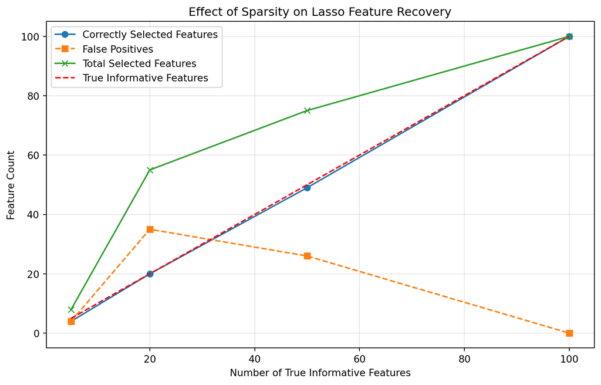

```python
n_samples = 300
n_features = 100
noise_level = 1.0
sparsity_levels = [5, 20, 50, 100]
results = []
np.random.seed(42)

for n_informative in sparsity_levels:
    X = np.random.randn(n_samples, n_features)
    true_coefficients = np.zeros(n_features)
    informative_features = np.random.choice(n_features, n_informative, replace=False)
    for idx in informative_features:
        true_coefficients[idx] = np.random.randn() * 3
    Y = X @ true_coefficients + np.random.randn(n_samples) * noise_level
    X_train, X_test, Y_train, Y_test = train_test_split(X, Y, test_size=0.3, random_state=42)
    scaler = StandardScaler()
    X_train_scaled = scaler.fit_transform(X_train)
    X_test_scaled = scaler.transform(X_test)
    lasso_cv = LassoCV(alphas=np.linspace(0.0001, 0.3, 50), cv=5, max_iter=10000)
    lasso_cv.fit(X_train_scaled, Y_train)
    nonzero_coef = np.sum(lasso_cv.coef_ != 0)
    correctly_identified = np.sum((lasso_cv.coef_ != 0) & (true_coefficients != 0))
    false_positives = np.sum((lasso_cv.coef_ != 0) & (true_coefficients == 0))
    results.append({
        'Informative Features': n_informative,
        'Optimal Alpha': lasso_cv.alpha_,
        'Test R²': r2_score(Y_test, lasso_cv.predict(X_test_scaled)),
        'Test MSE': mean_squared_error(Y_test, lasso_cv.predict(X_test_scaled)),
        'Non-zero Coefficients': nonzero_coef,
        'Correctly Selected': correctly_identified,
        'False Positives': false_positives
    })

result_df = pd.DataFrame(results)
print(result_df)

plt.figure(figsize=(10, 6))
plt.plot(result_df['Informative Features'], result_df['Correctly Selected'], 'o-', label='Correctly Selected Features')
plt.plot(result_df['Informative Features'], result_df['False Positives'], 's--', label='False Positives')
plt.plot(result_df['Informative Features'], result_df['Non-zero Coefficients'], 'x-', label='Total Selected Features')
plt.plot(sparsity_levels, sparsity_levels, 'r--', label='True Informative Features')
plt.xlabel('Number of True Informative Features')
plt.ylabel('Feature Count')
plt.title('Effect of Sparsity on Lasso Feature Recovery')
plt.legend()
plt.grid(True, alpha=0.3)
plt.show()
```

## Exercise 3: Correlated Features

This section introduces correlation among features to examine its impact on Lasso’s performance.

```
Optimal alpha: 0.0368
Correctly selected features: 10 / 10
False positives: 10
Test R²: 0.9903
Test MSE: 0.9164
```

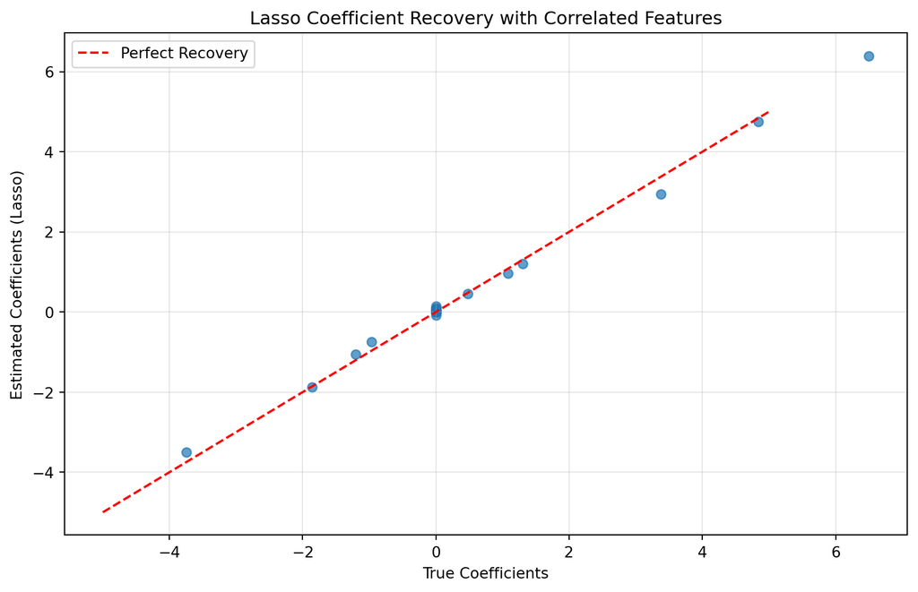

```python
n_samples = 300
n_features = 50
n_informative = 10
noise_level = 1.0
correlation_level = 0.8

np.random.seed(42)

correlation_matrix = np.eye(n_features)
for i in range(n_features):
    for j in range(n_features):
        if i != j:
            correlation_matrix[i, j] = correlation_level

mean = np.zeros(n_features)
X = np.random.multivariate_normal(mean, correlation_matrix, size=n_samples)

true_coefficients = np.zeros(n_features)
informative_features = np.random.choice(n_features, n_informative, replace=False)
for idx in informative_features:
    true_coefficients[idx] = np.random.randn() * 3

Y = X @ true_coefficients + np.random.randn(n_samples) * noise_level
X_train, X_test, Y_train, Y_test = train_test_split(X, Y, test_size=0.3, random_state=42)
scaler = StandardScaler()
X_train_scaled = scaler.fit_transform(X_train)
X_test_scaled = scaler.transform(X_test)

lasso_cv = LassoCV(alphas=np.linspace(0.0001, 0.3, 50), cv=5, max_iter=10000)
lasso_cv.fit(X_train_scaled, Y_train)

nonzero_coef = np.sum(lasso_cv.coef_ != 0)
correctly_identified = np.sum((lasso_cv.coef_ != 0) & (true_coefficients != 0))
false_positives = np.sum((lasso_cv.coef_ != 0) & (true_coefficients == 0))

print(f"Optimal alpha: {lasso_cv.alpha_:.4f}")
print(f"Correctly selected features: {correctly_identified} / {n_informative}")
print(f"False positives: {false_positives}")
print(f"Test R²: {r2_score(Y_test, lasso_cv.predict(X_test_scaled)):.4f}")
print(f"Test MSE: {mean_squared_error(Y_test, lasso_cv.predict(X_test_scaled)):.4f}")

plt.figure(figsize=(10, 6))
plt.scatter(true_coefficients, lasso_cv.coef_, alpha=0.7)
plt.plot([-5, 5], [-5, 5], 'r--', label='Perfect Recovery')
plt.xlabel('True Coefficients')
plt.ylabel('Estimated Coefficients (Lasso)')
plt.title('Lasso Coefficient Recovery with Correlated Features')
plt.legend()
plt.grid(True, alpha=0.3)
plt.show()
```

## Exercise 3: Interpretation

1. Why does Lasso perform feature selection while Ridge doesn’t?
2. In what situations would you prefer Lasso over Ridge?
3. What are the limitations of Lasso for feature selection?

The Lasso (Least Absolute Shrinkage and Selection Operator) performs feature selection because it has L1 regularization so that it penalizes the absolute values of regression coefficients.

That penalty does an interesting thing which is to exactly zero some of the coefficients during optimization since it is penalizing the size of the numbers (shrinking them all toward zero). In contrast Ridge uses L2 or squared regularization meaning that instead of penalizing large betas, it penalizes the square of them.

Coefficient shrinkage using L2 regularization leads to the loss of some coefficients, but only rarely to zero and always warrants shrinkage hence Ridge deletes nothing from your finally model.(Fairly keeps all features with low importance)

In the case we’ll only have a few number of truly informative features (i.e., data is sparse), Lasso is preferred because I think it adheres to Occam’s razor. It is great for interpretability, as it cleans up the model by getting rid of less important predictors. In high-dimensional cases (number of features larger than samples) will also regularize with Lasso, thus reducing overfitting (decreasing number of model parameters).

Unfortunately this is one of the barriers that Lasso has. Perhaps the most problematic limitation of all is its instability when features are very highly correlated — it will pick “one feature out of many that are perfectly correlated”, which incurs inconsistencies in variable selection.

Moreover, in high-dimensional or even moderate dimensional settings where the number of informative features is large relative to the number of samples, Lasso can do poorly or pick very few of the true predictors when the true effects are small and spread out. In this case, Ridge or elastic net (L1 + L2 penalty) might be better balance between regularization criteria applied and numbers of features retained.